# 5. ggplot2 (Lollipop Chart)

Masahiko Asano

2026-07-23

- **このセクションで使っている `R packages`**

```r
library(DT)
library(gapminder)
library(gghighlight)
library(ggrepel)
library(stargazer)
library(tidyverse)
```

# 1. Lollipop Chart

- The lollipop chart (dot plot) is visually uncluttered and easy to read, so it is used as an alternative to bar graphs and histograms.
- Use data processed from the results of the House of Representatives elections (single-member districts) conducted from 2009 to 2014.
- The dataset contains the following 7 variables:

| Variable Name | Details |
| --- | --- |
| year | The year the House of Representatives election was held |
| pref | Prefecture name (in Japanese) |
| id | Prefecture id (1-47) |
| nosmd | Total number of single-member districts in the prefecture (1-25) |
| ldp | Total number of Liberal Democratic Party candidates elected in the prefecture’s single-member districts |
| ldp_ratio | Percentage of LDP winners in the total number of single-member districts in the prefecture (%) |
| dpj | Total number of Democratic Party candidates elected in the prefecture’s single-member districts |

- Download the data hr09-14_ldp_seatshare.csv  
  → Place it in the data folder created inside the R project folder.
- Load this `csv` file and name it `df_seat`

```r
df_seat <- read_csv("data/hr09_14_ldp_seatshare.csv")
```

- Use the `datatable()` function to check the contents of the dataframe, `df_seat`

```r
DT::datatable(df_seat)
```

|  | year | pref | id | nosmd | ldp | ldp_ratio | dpj |
| --- | --- | --- | --- | --- | --- | --- | --- |
| 1 | 2012 | 愛知 | 1 | 15 | 13 | 87 | 2 |
| 2 | 2014 | 愛知 | 1 | 15 | 8 | 53 | 3 |
| 3 | 2009 | 愛知 | 1 | 15 | 0 | 0 | 15 |
| 4 | 2012 | 秋田 | 2 | 3 | 3 | 100 | 0 |
| 5 | 2014 | 秋田 | 2 | 3 | 3 | 100 | 0 |
| 6 | 2009 | 秋田 | 2 | 3 | 0 | 0 | 2 |
| 7 | 2012 | 青森 | 3 | 4 | 4 | 100 | 0 |
| 8 | 2014 | 青森 | 3 | 4 | 4 | 100 | 0 |
| 9 | 2009 | 青森 | 3 | 4 | 3 | 75 | 1 |
| 10 | 2012 | 千葉 | 4 | 13 | 11 | 85 | 2 |

[output cut: 131 more lines]

## 1.1 1.1 Basic Lollipop Chart

- Extract only the data from the 2009 House of Representatives election.
- The most basic lollipop chart can be displayed as follows:

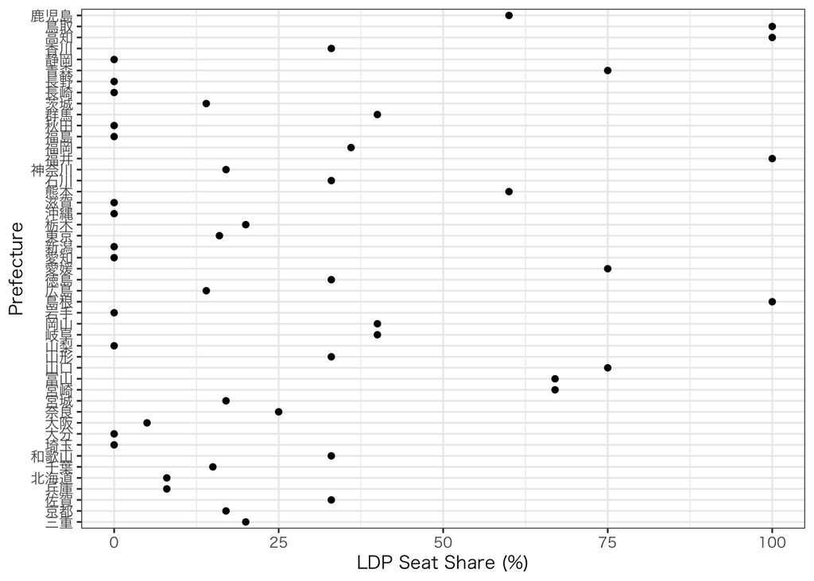

```r
df_seat %>%
  dplyr::filter(year == 2009) %>%
  ggplot(aes(x = ldp_ratio,
             y = pref)) +
  geom_point() +
  theme_bw(base_family = "HiraKakuProN-W3")+
    labs(x = "LDP Seat Share (%)",
         y = "Prefecture")
```

- Use the `reorder()` function to sort the prefectures in descending order of the proportion of LDP winners (`ldp_ratio`) to create a more readable lollipop chart.

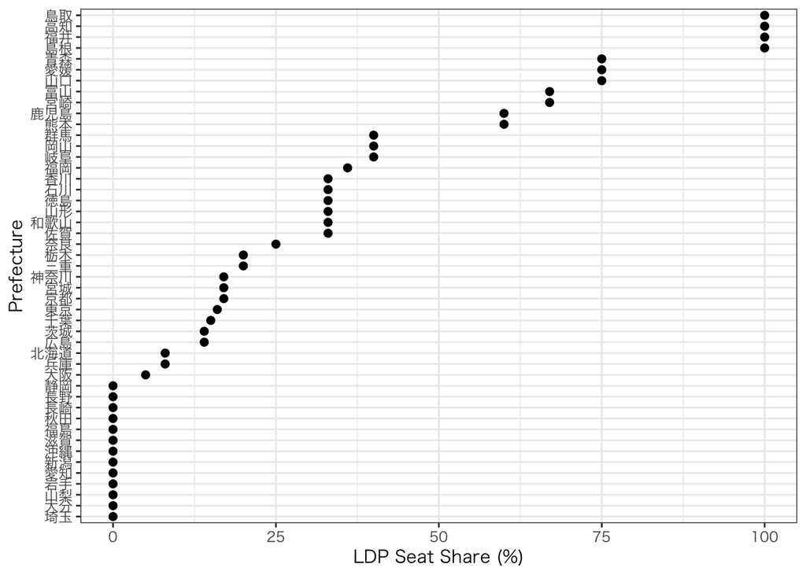

```r
df_seat %>%
  dplyr::filter(year == 2009) %>%
  ggplot(aes(x = ldp_ratio,
             y = reorder(pref, ldp_ratio))) + # reorder pref based on ldp_ratio
  geom_point(size = 2) +
  theme(panel.grid.major.x = element_blank(),
        panel.grid.minor.x = element_blank(),
        panel.grid.major.y = element_line(colour = "grey60", linetype = "dashed")) +
  theme_bw(base_family = "HiraKakuProN-W3") +
    labs(x = "LDP Seat Share (%)",
         y = "Prefecture")
```

## 1.2 Grouped Lollipop Chart

- Next, using the `facet()` function, we’ll display how the LDP’s seat share has changed in each prefecture across the three House of Representatives elections in 2009, 2012, and 2014, using lollipop charts.
- To display by election year (`year`), we’ll convert the `year` variable into a `factor`, then sort the LDP’s seat share from the 2009 House of Representatives election, and display the LDP’s winning seat share for each prefecture for all three elections.
- We’ll check the data type of the election year (`year`) used for grouping.

```r
str(df_seat$year)
```

```
 num [1:141] 2012 2014 2009 2012 2014 ...
```

- Since the variable `year` is `numeric`, convert it to `factor.`

```r
df_seat$year <- factor(df_seat$year)
```

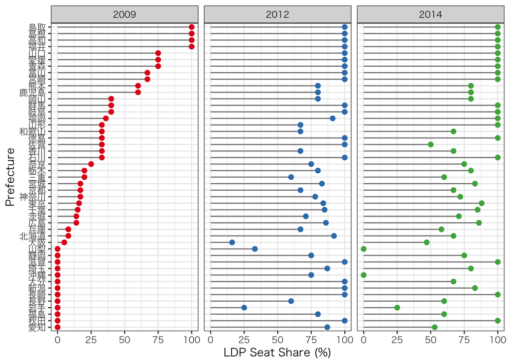

```r
df_seat %>%
  arrange(year, ldp_ratio) %>%
  mutate(order_seq = c(1:47, rep(0, 47*2))) %>%  # add a variable `order_seq`

  ggplot(aes(x = ldp_ratio,
             y = reorder(pref, order_seq))) +
  geom_segment(aes(yend = pref),
               xend = 0, colour = "grey50") +
  geom_point(size = 2,
             aes(colour = year)) +
  scale_colour_brewer(palette = "Set1",
                      limits = c("2009", "2012", "2014"),
                      guide = FALSE) +
  theme(panel.grid.major.y =
          element_blank()) +
  facet_grid(~ year,
             scales="free_y", space = "free_y") +
  theme_bw(base_family = "HiraKakuProN-W3")+
    labs(x = "LDP Seat Share (%)",
         y = "Prefecture")
```

**The proportion of Liberal Democratic Party candidates elected in the single-member districts of the House of Representatives elections from 2009 to 2014, by prefecture.**

- If represented as a histogram, it would look like this:

```r
# year変数を factor に変換する
df_seat$year <- factor(df_seat$year)
```

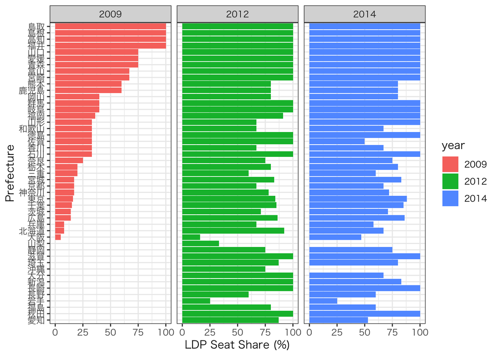

```r
df_seat %>%
  arrange(year, ldp_ratio) %>%
  mutate(order_seq = c(1:47, rep(0, 47*2))) %>%

  ggplot(aes(x = reorder(pref, order_seq),
           y = ldp_ratio,
           fill = year)) +
  geom_bar(stat = "identity") +
  facet_grid(~ year, scales = "free_x") +
  theme(legend.position = "none") +
  coord_flip()+
  theme_bw(base_family = "HiraKakuProN-W3")+
    labs(x = "Prefecture",
         y = "LDP Seat Share (%)")
```

**The proportion of Liberal Democratic Party candidates elected in the single-member districts of the House of Representatives elections from 2009 to 2014, by prefecture.**

## 2 Exercise

#### Q2.1:

- Using the method from `1.1 Basic Lollipop Chart`, create a new variable showing the percentage of Democratic Party winners in the total number of single-member districts within each prefecture for the 2009 general election.
- Name this variable `dpj_ratio` and draw a lollipop chart.
- Use the data downloaded from hr09_14_ldp_seatshare.csv

#### Q2.2:

- Using the method from `1.2 Grouped Lollipop Chart`, draw a histogram showing the percentage of Democratic Party winners in the total number of single-member districts within each prefecture for the 2009, 2012, and 2014 general elections.
- Use the data downloaded from hr09_14_ldp_seatshare.csv

#### Q2.3:

- What can be inferred from these results?

**Reference**

[Tidy Animated Verbs](https://github.com/gadenbuie/tidyexplain?fbclid=IwAR3Zt0pQZa0IEvP-1gstatQ42VM5yJZvw2vUaFEqt_m2smUgtZpTqvuurLJ6z0)

[宋財泫 (Jaehyun Song)・矢内勇生 (statuki statanai)「私たちのR: ベストプラクティスの探究」](https://www.jaysong.net/RBook/)

[宋財泫「ミクロ政治データ分析実習（2022年度）」](https://www.jaysong.net/micro-book/)

[土井翔平（北海道大学公共政策大学院）「Rで計量政治学入門」](https://shohei-doi.github.io/quant_polisci/data-import.html)

[矢内勇生（高知工科大学）授業一覧](http://yukiyanai.github.io/teaching/)

浅野正彦, 矢内勇生.『Rによる計量政治学』オーム社、2018年

浅野正彦, 中村公亮.『初めてのRStudio』オーム社、2018年

Kieran Healy, DATA VISUALIZATION, Princeton, 2019

Kosuke Imai, Quantitative Social Science: An Introduction, Princeton University Press, 2017